# lab9

Tiffany Nguyen

2025-04-03

# Task 1

```r
getwd()
```

```
## [1] "/Users/tiffanynguyen/Documents/College/Sophomore/Spring_2025/Applied_Statistical_Methods/MATH4753nguy0850/labs/lab9"
```

# Task 2

Line A creates a large vector of resamples with replacement and n*iter is used to create a matrix of values corresponding to the amount of samples.

Line B creates the intervals of confidence by finding the quantiles of the xstat vector and a range of values from alpha/2 to 1-alpha/2. The xstat vector contains statistics from the boostrapping samples.

It is necessary to sample each datum in x with equal probability because it allows for the resampling values to be unbiased and accurate for the confidence intervals.

```r
set.seed(35)
sam=round(rnorm(20,mean=10,sd=4),2)

# with replacement
unique(sample(sam,20,replace=TRUE) ) # repeat this line 5Xs
```

```
##  [1] 12.05 23.35 11.40 14.26  8.43 13.46  2.37  8.62 17.35 11.64 14.76  9.82
```

```r
unique(sample(sam,20,replace=TRUE) ) # repeat this line 5Xs
```

```
##  [1]  8.43 14.26  7.75  2.89 12.05  2.37  9.82 13.46  6.93 10.53 23.35 11.78
## [13]  8.62 11.40  9.86
```

```r
unique(sample(sam,20,replace=TRUE) ) # repeat this line 5Xs
```

```
##  [1]  9.86 10.53 14.26 17.35 12.05  6.93 23.35  8.62 11.64 16.69 11.40
```

```r
unique(sample(sam,20,replace=TRUE) ) # repeat this line 5Xs
```

```
##  [1] 11.64  9.82  8.62 17.35 11.78 11.40  7.75  2.37 23.35  2.89
```

```r
unique(sample(sam,20,replace=TRUE) ) # repeat this line 5Xs
```

```
##  [1]  7.75 14.76 16.69 17.35 14.26  8.62 11.40  8.43 12.05  2.89 10.53 23.35
```

```r
# without replacement
unique(sample(sam,20,replace=FALSE) ) # repeat this line 5Xs
```

```
##  [1] 14.26 13.46  7.75 16.69  9.82  8.43 12.05 14.76 17.35  2.89 10.53  8.00
## [13]  8.62  2.37  6.93  9.86 11.78 11.64 11.40 23.35
```

```r
unique(sample(sam,20,replace=FALSE) ) # repeat this line 5Xs
```

```
##  [1] 14.26 13.46 17.35  8.62  7.75  8.00 10.53  2.89 16.69  9.82  2.37  6.93
## [13]  8.43  9.86 12.05 11.40 11.64 14.76 23.35 11.78
```

```r
unique(sample(sam,20,replace=FALSE) ) # repeat this line 5Xs
```

```
##  [1] 23.35  7.75 16.69  6.93 11.78 17.35 10.53 13.46  2.37 11.64  2.89 14.76
## [13] 11.40 12.05  9.86  8.00 14.26  8.62  9.82  8.43
```

```r
unique(sample(sam,20,replace=FALSE) ) # repeat this line 5Xs
```

```
##  [1]  9.86 12.05 11.64  8.00 16.69  7.75  8.62 23.35 14.26 13.46  9.82  8.43
## [13]  2.37 11.78  2.89 10.53 14.76  6.93 17.35 11.40
```

```r
unique(sample(sam,20,replace=FALSE) ) # repeat this line 5Xs
```

```
##  [1] 14.26  6.93  9.86  9.82  8.00  7.75 11.40 13.46  8.43 17.35  8.62 11.78
## [13] 12.05  2.37 16.69 11.64  2.89 10.53 23.35 14.76
```

```r
# sample(sam,21,replace=FALSE)
```

With replacement: The number of unique values in the sample may be less than 20 because the same element can be chosen multiple times.

Without replacement: The number of unique values will always be 20 (in this case), because each element can only be chosen once.

sample(sam,21,replace=FALSE): this piece of code can’t run because it is impossible to take a sample of 21 elements from a vector of 20 elements. There is no replacement, so each value in the vector can be chosen only once.

# Task 3

### myboot function

```r
myboot<-function(iter=10000,x,fun="mean",alpha=0.05,...){

  #Notice where the ... is repeated in the code
  n=length(x)   #sample size

  #Now sample with replacement
  y=sample(x,n*iter,replace=TRUE) #A

  # Make a matrix with all the resampled values
  rs.mat=matrix(y,nr=n,nc=iter,byrow=TRUE)
  xstat=apply(rs.mat,2,fun)
  # xstat is a vector and will have iter values in it
  ci=quantile(xstat,c(alpha/2,1-alpha/2)) #B
  # Nice way to form a confidence interval
  # A histogram follows
  # The object para will contain the parameters used to make the histogram
  para=hist(xstat,freq=FALSE,las=1,main="Histogram of Bootstrap sample statistics",...)

  #mat will be a matrix that contains the data, this is done so that I can use apply()
  mat=matrix(x,nr=length(x),nc=1,byrow=TRUE)

  #pte is the point estimate
  #This uses whatever fun is
  pte=apply(mat,2,fun)
  abline(v=pte,lwd=3,col="Black")# Vertical line
  segments(ci[1],0,ci[2],0,lwd=4)      #Make the segment for the ci
  text(ci[1],0,paste("(",round(ci[1],2),sep=""),col="Red",cex=3)
  text(ci[2],0,paste(round(ci[2],2),")",sep=""),col="Red",cex=3)

  # plot the point estimate 1/2 way up the density
  text(pte,max(para$density)/2,round(pte,2),cex=3)

  return(list(ci=ci,fun=fun,x=x))# Some output to use if necessary

}


myboot2<-function(iter=10000,x,fun="mean",alpha=0.05,cx=1.5,...){  #Notice where the ... is repeated in the code

  n=length(x)   #sample size

  y=sample(x,n*iter,replace=TRUE)
  rs.mat=matrix(y,nr=n,nc=iter,byrow=TRUE)
  xstat=apply(rs.mat,2,fun) # xstat is a vector and will have iter values in it
  ci=quantile(xstat,c(alpha/2,1-alpha/2))# Nice way to form a confidence interval
  # A histogram follows
  # The object para will contain the parameters used to make the histogram
  para=hist(xstat,freq=FALSE,las=1,
  main=paste("Histogram of Bootstrap sample statistics","\n","alpha=",alpha," iter=",iter,sep=""),
  ...)

  #mat will be a matrix that contains the data, this is done so that I can use apply()
  mat=matrix(x,nr=length(x),nc=1,byrow=TRUE)

  #pte is the point estimate
  #This uses whatever fun is
  pte=apply(mat,2,fun)
  abline(v=pte,lwd=3,col="Black")# Vertical line
  segments(ci[1],0,ci[2],0,lwd=4)      #Make the segment for the ci
  text(ci[1],0,paste("(",round(ci[1],2),sep=""),col="Red",cex=cx)
  text(ci[2],0,paste(round(ci[2],2),")",sep=""),col="Red",cex=cx)

  # plot the point estimate 1/2 way up the density
  text(pte,max(para$density)/2,round(pte,2),cex=cx)

  invisible(list(ci=ci,fun=fun,x=x))# Some output to use if necessary

}
```

### mean

```r
# rnorm
set.seed(39)
sam=rnorm(25,mean=25,sd=10)
rnorm_result <- myboot(iter=10000,x=sam,fun=mean,alpha=0.05)
```

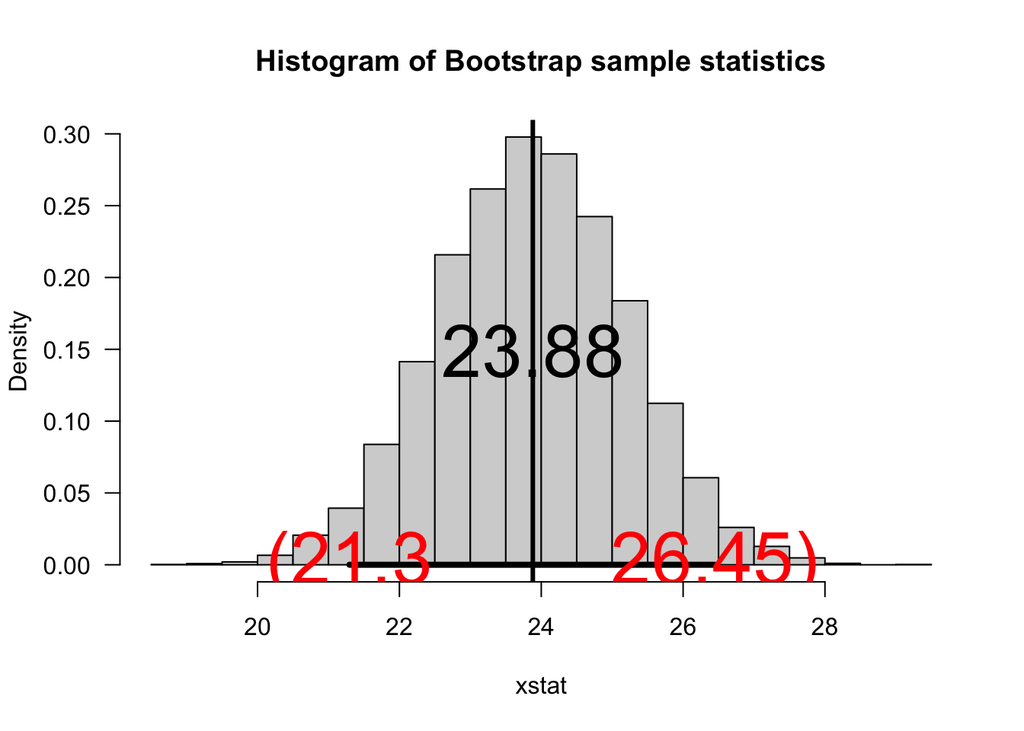

```r
pop_mean1 <- 25
# yes the interval contain the population mean
data.frame(Interval = rnorm_result$ci, Population_Mean = pop_mean1, Point_Estimate = rnorm_result$fun(rnorm_result$x))
```

```
##       Interval Population_Mean Point_Estimate
## 2.5%  21.29544              25       23.88103
## 97.5% 26.44594              25       23.88103
```

```r
# rchisq
set.seed(30)
sam=rchisq(20,df=3)
rchisq_result <- myboot(iter=10000,x=sam,fun=mean,alpha=0.05)
```

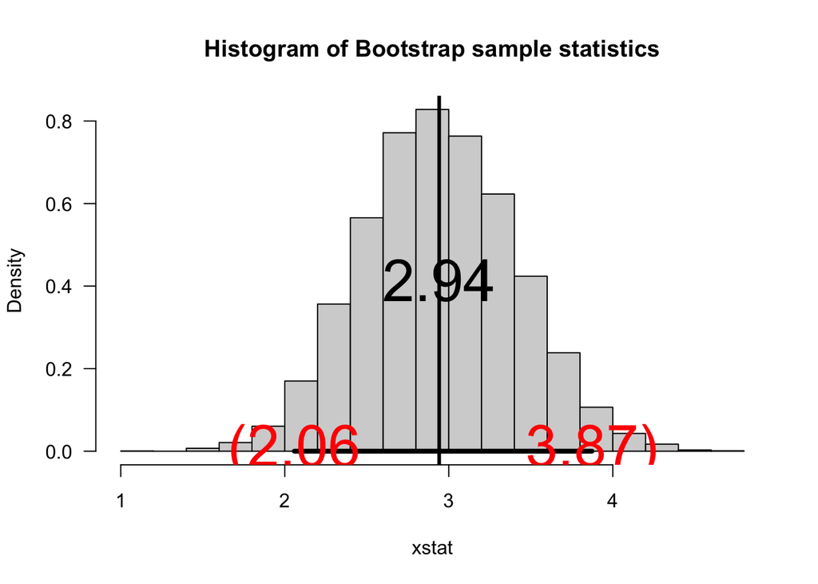

```r
pop_mean2 <- 3
# yes the interval contain the population mean
data.frame(Interval = rchisq_result$ci, Population_Mean = pop_mean2, Point_Estimate = rchisq_result$fun(rchisq_result$x))
```

```
##       Interval Population_Mean Point_Estimate
## 2.5%  2.058324               3       2.941449
## 97.5% 3.872860               3       2.941449
```

```r
# rgamma
set.seed(40)
sam=rgamma(30,shape=2,scale=3)
rgamma_result <- myboot(iter=10000,x=sam,fun=mean,alpha=0.05)
```

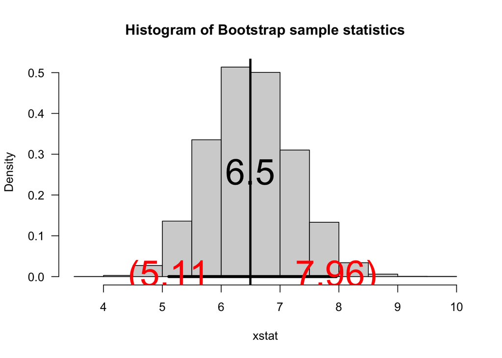

```r
pop_mean3 <- 2*3
# yes the interval contain the population mean
data.frame(Interval = rgamma_result$ci, Population_Mean = pop_mean3, Point_Estimate = rgamma_result$fun(rgamma_result$x))
```

```
##       Interval Population_Mean Point_Estimate
## 2.5%  5.109096               6       6.495501
## 97.5% 7.955578               6       6.495501
```

```r
# rbeta
set.seed(10)
sam=rbeta(20,shape1=3,shape2=4)
rbeta_result <- myboot(iter=10000,x=sam,fun=mean,alpha=0.05)
```

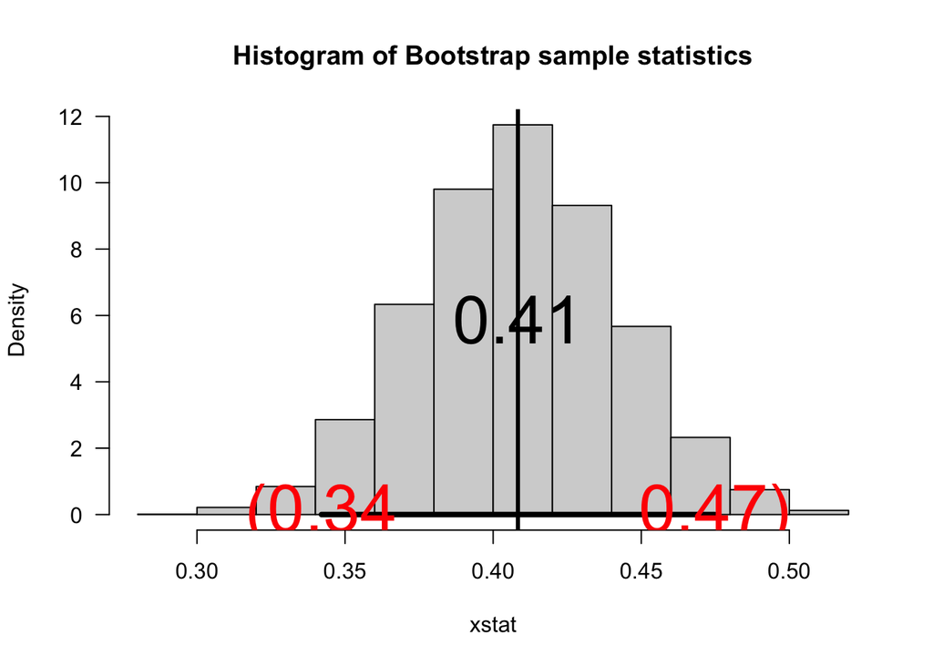

```r
pop_mean4 <- 3/(3+4)
data.frame(Interval = rbeta_result$ci, Population_Mean = pop_mean4, Point_Estimate = rbeta_result$fun(rbeta_result$x))
```

```
##        Interval Population_Mean Point_Estimate
## 2.5%  0.3420448       0.4285714      0.4083684
## 97.5% 0.4747873       0.4285714      0.4083684
```

### variance

```r
# rnorm
set.seed(39)
sam <- rnorm(25,mean=25,sd=10)
rnorm2_result <- myboot(iter=10000,x=sam,fun=var,alpha=0.20)
```

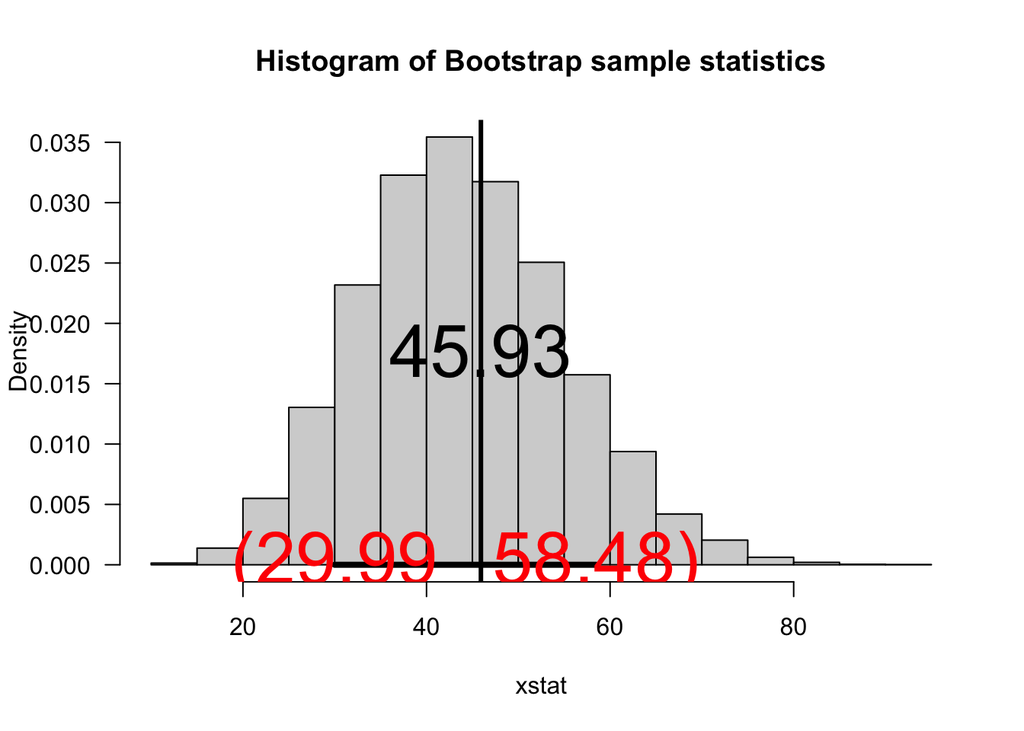

```r
pop_var1 <- 10^2
data.frame(Interval = rnorm2_result$ci, Population_Variance = pop_var1, Point_Estimate = rnorm2_result$fun(rnorm2_result$x))
```

```
##     Interval Population_Variance Point_Estimate
## 10% 29.98686                 100       45.92561
## 90% 58.47769                 100       45.92561
```

```r
# rchisq
set.seed(30)
sam=rchisq(20,df=3)
rchisq2_result <- myboot(iter=10000,x=sam,fun=var,alpha=0.20)
```

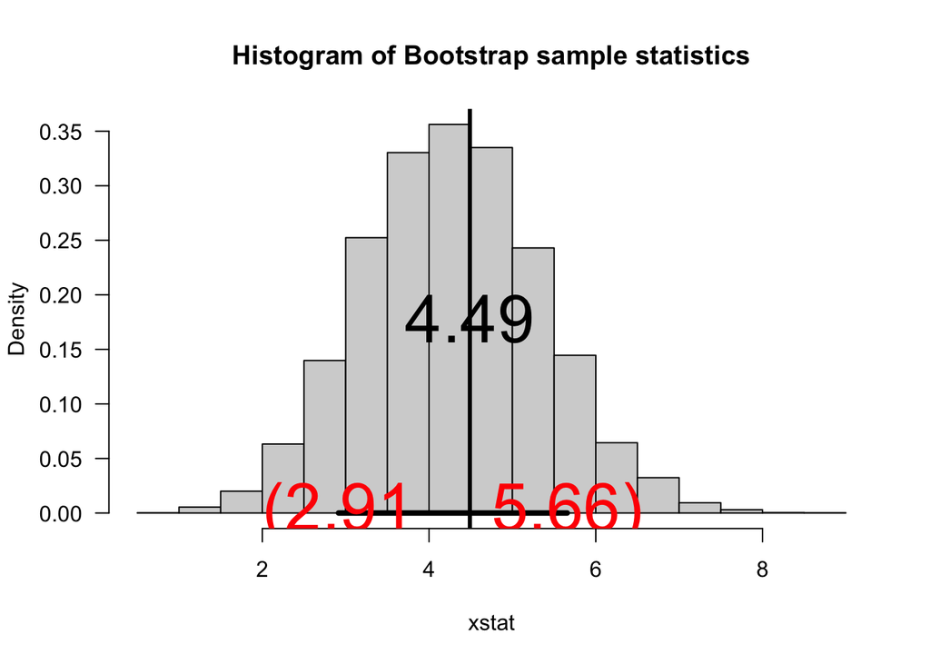

```r
pop_var2 <- 3^2
data.frame(Interval = rchisq2_result$ci, Population_Variance = pop_var2, Point_Estimate = rchisq2_result$fun(rchisq2_result$x))
```

```
##     Interval Population_Variance Point_Estimate
## 10% 2.914578                   9       4.489942
## 90% 5.657453                   9       4.489942
```

```r
# rgamma
set.seed(40)
sam=rgamma(30,shape=2,scale=3)
rgamma2_result <- myboot(iter=10000,x=sam,fun=var,alpha=0.20)
```

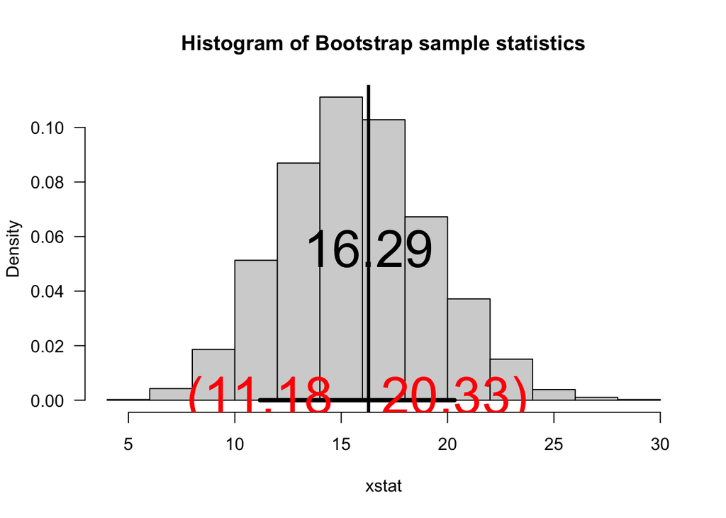

```r
pop_var3 <- 2*3^2
data.frame(Interval = rgamma2_result$ci, Population_Variance = pop_var3, Point_Estimate = rgamma2_result$fun(rgamma2_result$x))
```

```
##     Interval Population_Variance Point_Estimate
## 10% 11.18218                  18        16.2863
## 90% 20.32860                  18        16.2863
```

```r
# rbeta
set.seed(10)
sam=rbeta(20,shape1=3,shape2=4)
rbeta2_result <- myboot(iter=10000,x=sam,fun=var,alpha=0.20)
```

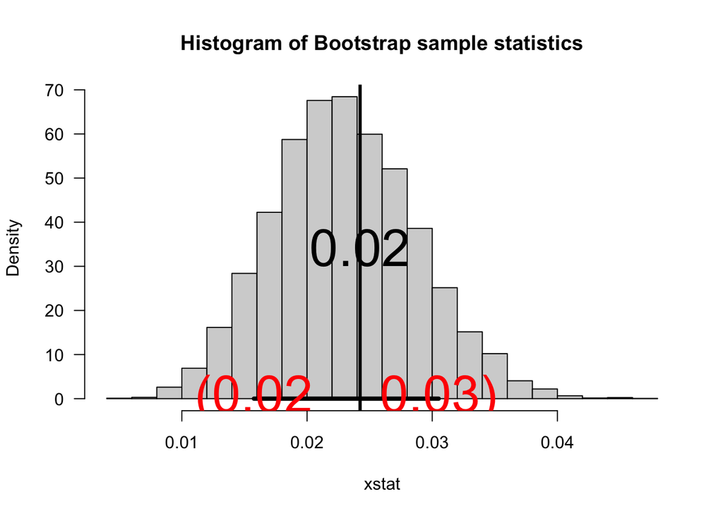

```r
pop_var4 <- (3*4^2)/(3+4)^2/(3+4+1)
data.frame(Interval = rbeta2_result$ci, Population_Variance = pop_var4, Point_Estimate = rbeta2_result$fun(rbeta2_result$x))
```

```
##       Interval Population_Variance Point_Estimate
## 10% 0.01575789            0.122449     0.02423739
## 90% 0.03051256            0.122449     0.02423739
```

# Task 4

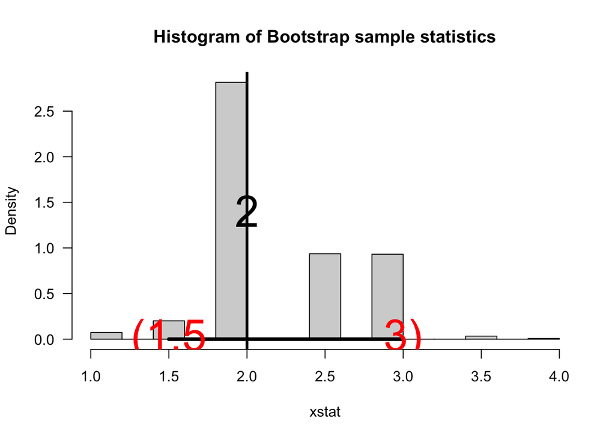

```r
myboot<-function(iter=10000,x,fun="mean",alpha=0.05,...){

  #Notice where the ... is repeated in the code
  n=length(x)   #sample size

  #Now sample with replacement
  y=sample(x,n*iter,replace=TRUE) #A

  # Make a matrix with all the resampled values
  rs.mat=matrix(y,nr=n,nc=iter,byrow=TRUE)
  xstat=apply(rs.mat,2,fun)
  # xstat is a vector and will have iter values in it
  ci=quantile(xstat,c(alpha/2,1-alpha/2)) #B
  # Nice way to form a confidence interval
  # A histogram follows
  # The object para will contain the parameters used to make the histogram
  para=hist(xstat,freq=FALSE,las=1,main="Histogram of Bootstrap sample statistics",...)

  #mat will be a matrix that contains the data, this is done so that I can use apply()
  mat=matrix(x,nr=length(x),nc=1,byrow=TRUE)

  #pte is the point estimate
  #This uses whatever fun is
  pte=apply(mat,2,fun)
  abline(v=pte,lwd=3,col="Black")# Vertical line
  segments(ci[1],0,ci[2],0,lwd=4)      #Make the segment for the ci
  text(ci[1],0,paste("(",round(ci[1],2),sep=""),col="Red",cex=3)
  text(ci[2],0,paste(round(ci[2],2),")",sep=""),col="Red",cex=3)

  # plot the point estimate 1/2 way up the density
  text(pte,max(para$density)/2,round(pte,2),cex=3)

  return(list(ci=ci, fun=fun, x=x, xstat=xstat)) # Some output to use if necessary

}

sam=c(1,1,1,2,2,2,2,3,3,3,4,4)
result_median <- myboot(x=sam,fun=median)
```

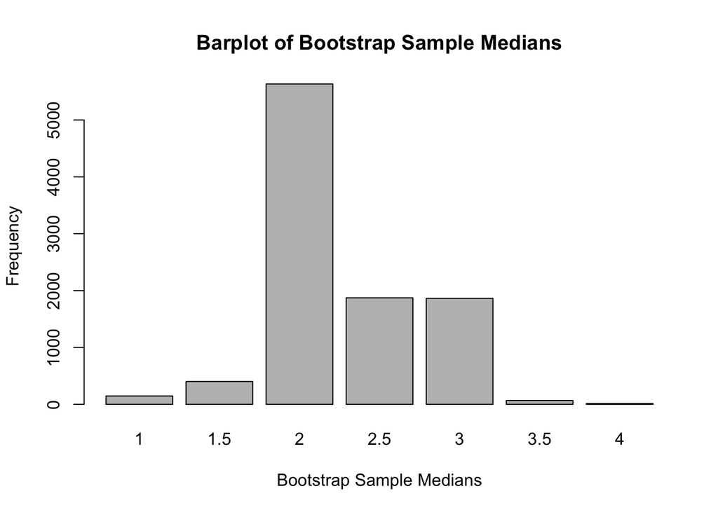

```r
barplot(table(result_median$xstat), main = "Barplot of Bootstrap Sample Medians", xlab = "Bootstrap Sample Medians", ylab = "Frequency")
```

```r
# interval estimate (L, U) second row
result_median$ci
```

```
##  2.5% 97.5%
##   1.5   3.0
```

# Task 5

```r
mean_median <- function(x) {
  return(mean(x) / median(x))
}

set.seed(39)
sam1=rnorm(25,mean=25,sd=10)

set.seed(30)
sam2=rchisq(20,df=3)

set.seed(40)
sam3=rgamma(30,shape=2,scale=3)

set.seed(10)
sam4=rbeta(20,shape1=3,shape2=4)

# 95%
r1_95 <- myboot(iter=10000,x=sam1,fun=mean_median,alpha=0.05)
```

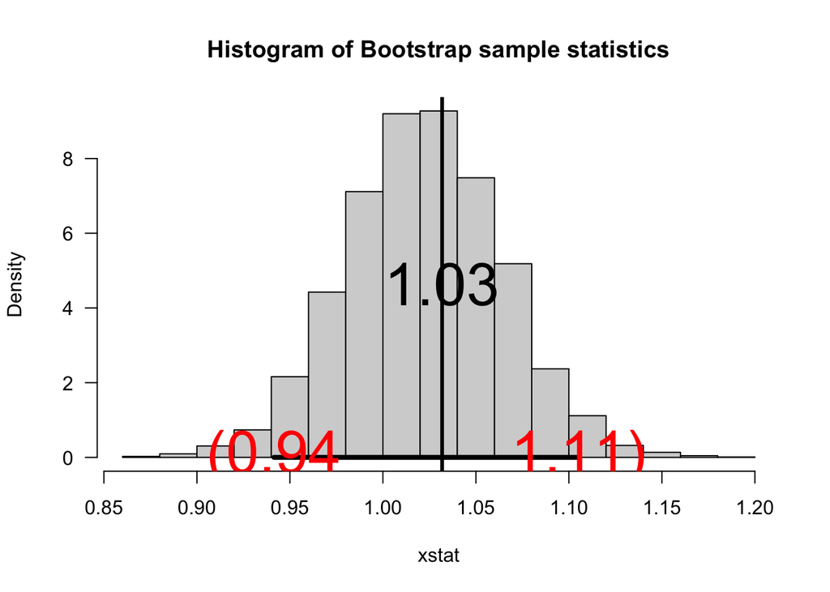

```r
r2_95 <- myboot(iter=10000,x=sam2,fun=mean_median,alpha=0.05)
```

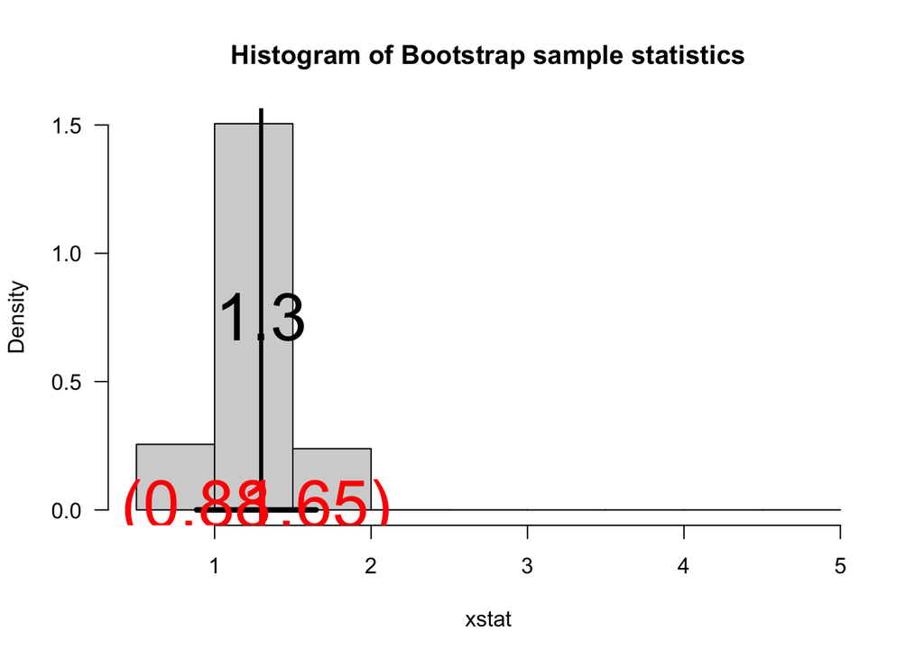

```r
r3_95 <- myboot(iter=10000,x=sam3,fun=mean_median,alpha=0.05)
```

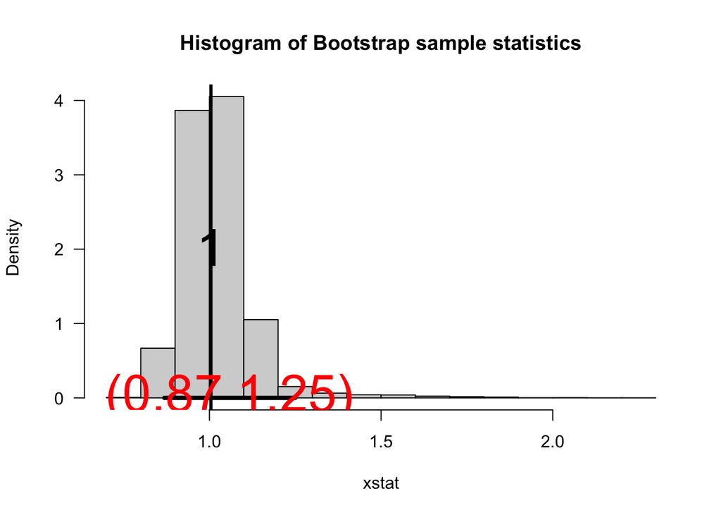

```r
r4_95 <- myboot(iter=10000,x=sam4,fun=mean_median,alpha=0.05)
```

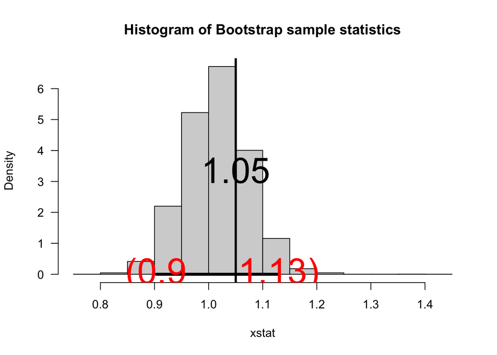

```r
results_95 <- list(A = r1_95$ci, B = r2_95$ci, C = r3_95$ci, D = r4_95$ci)

# 70%
r1_70 <- myboot(iter=10000,x=sam,fun=mean_median,alpha=0.30)
```

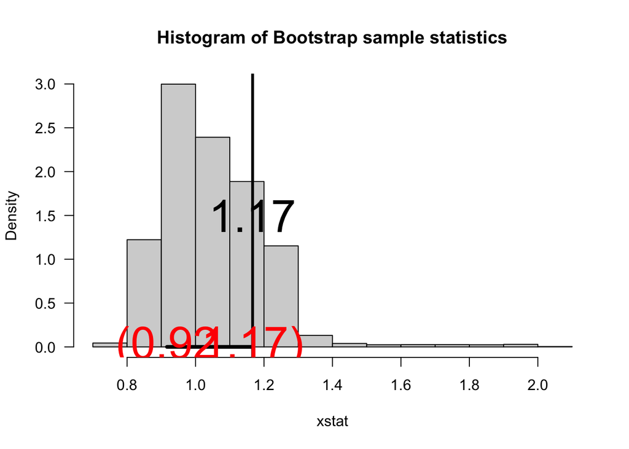

```r
r2_70 <- myboot(iter=10000,x=sam,fun=mean_median,alpha=0.30)
```

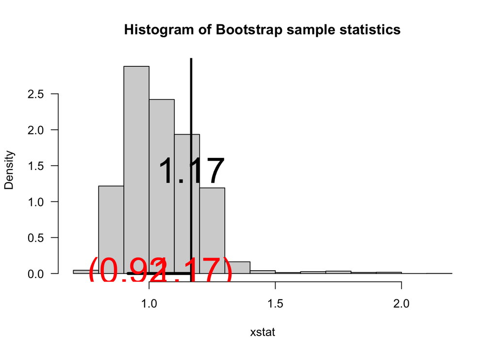

```r
r3_70 <- myboot(iter=10000,x=sam,fun=mean_median,alpha=0.30)
```

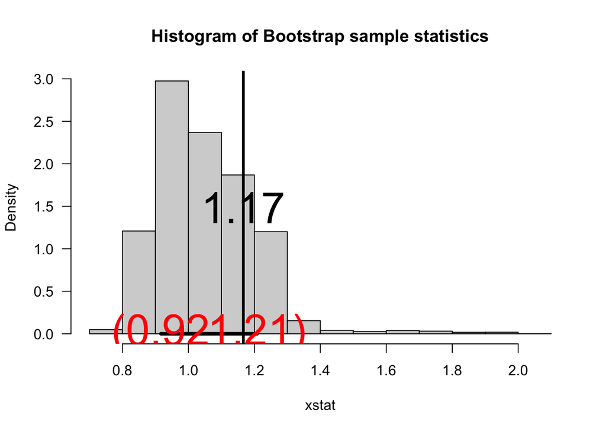

```r
r4_70 <- myboot(iter=10000,x=sam,fun=mean_median,alpha=0.30)
```

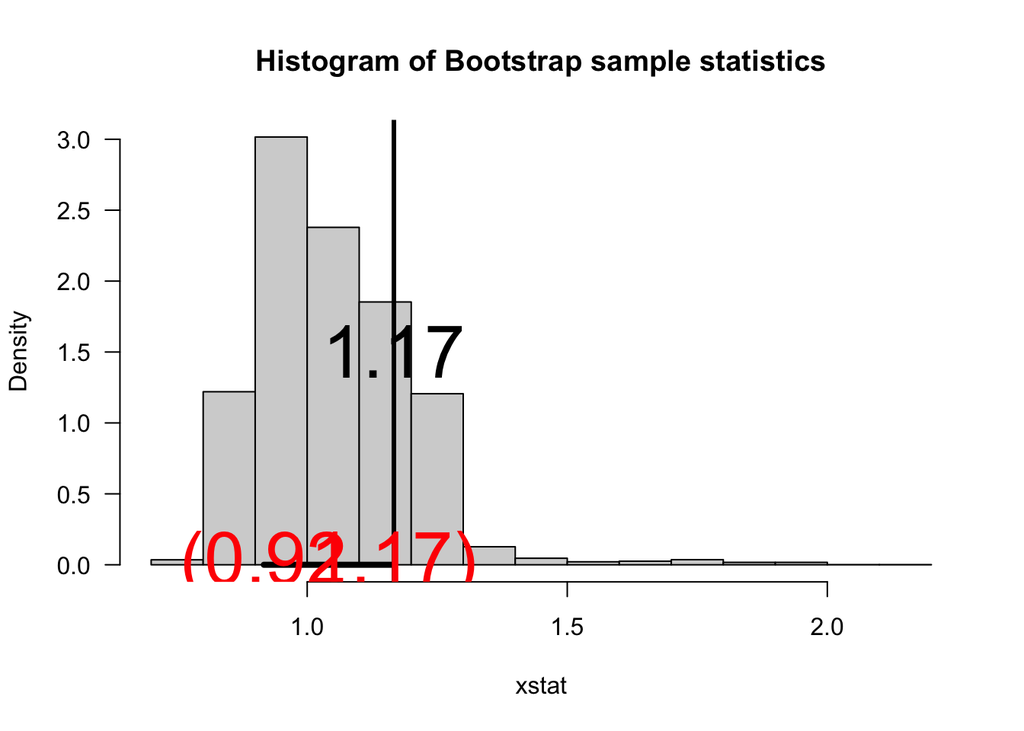

```r
results_70 <- list(A = r1_70$ci, B = r2_70$ci, C = r3_70$ci, D = r4_70$ci)
```

# Task 6

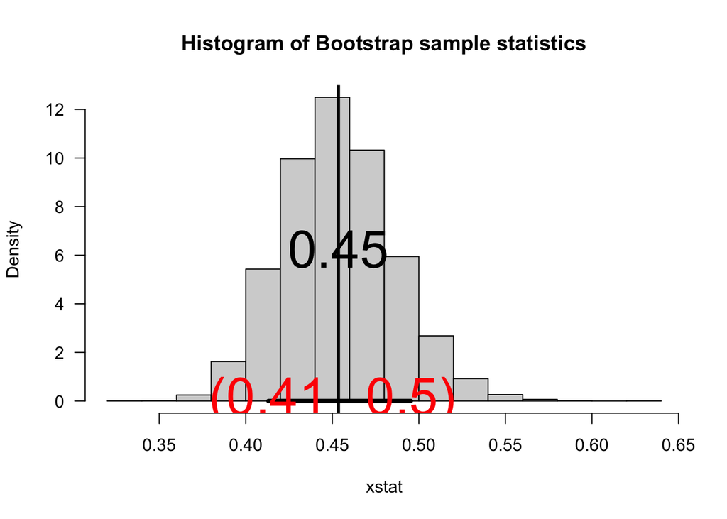

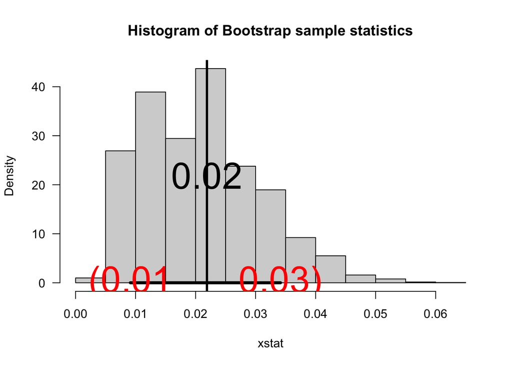

```
## $mean_ci
##       10%       90%
## 0.4130731 0.4953665
##
## $var_ci
##         10%         90%
## 0.009131531 0.034145151
```

```r
mean_var <- function(sample) {
  mean_result <- myboot(iter = 10000, x = sample, fun = mean, alpha = 0.20)
  var_result <- myboot(iter = 10000, x = sample, fun = var, alpha = 0.20)
  list(mean_ci = mean_result$ci, var_ci = var_result$ci)
}

# 4 fun random distributions
set.seed(100)
sam1=rbeta(20,shape1=3,shape2=4)
mean_var(sam1)
```

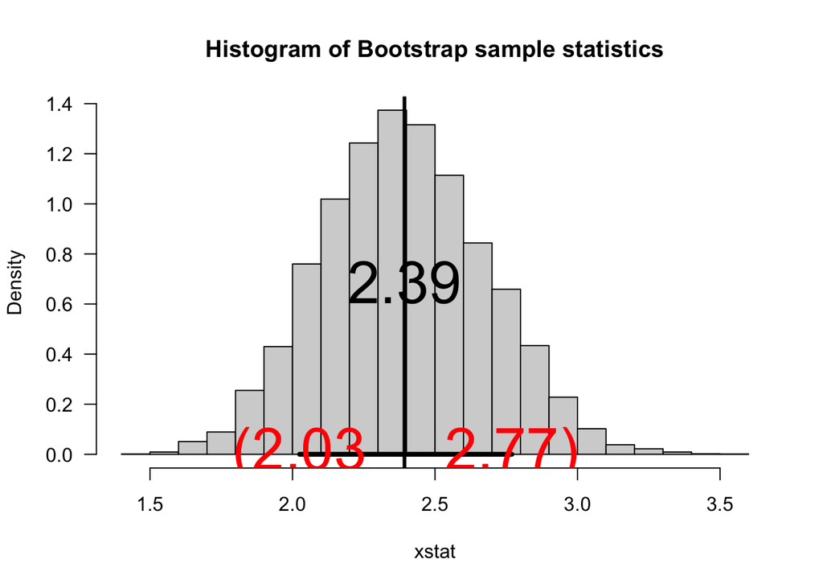

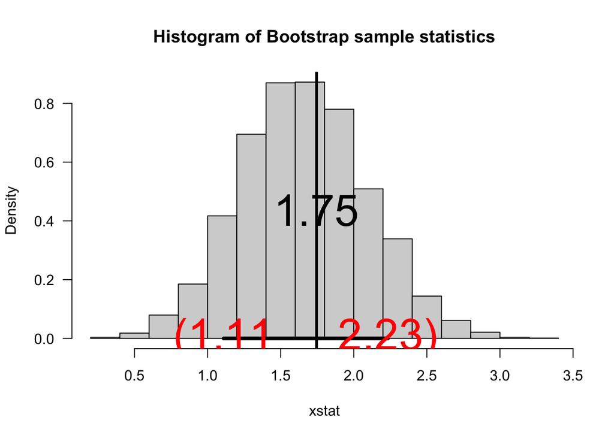

```
## $mean_ci
##      10%      90%
## 2.025071 2.769300
##
## $var_ci
##      10%      90%
## 1.109193 2.234070
```

```r
set.seed(110)
sam2=rweibull(20,shape=2,scale=3)
mean_var(sam2)
```

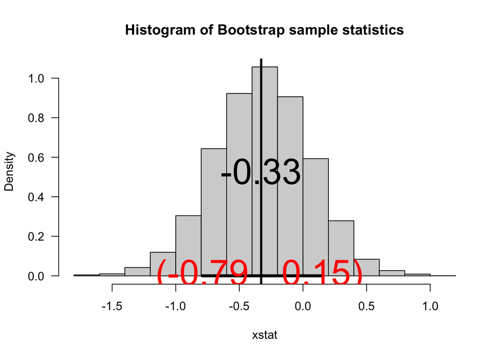

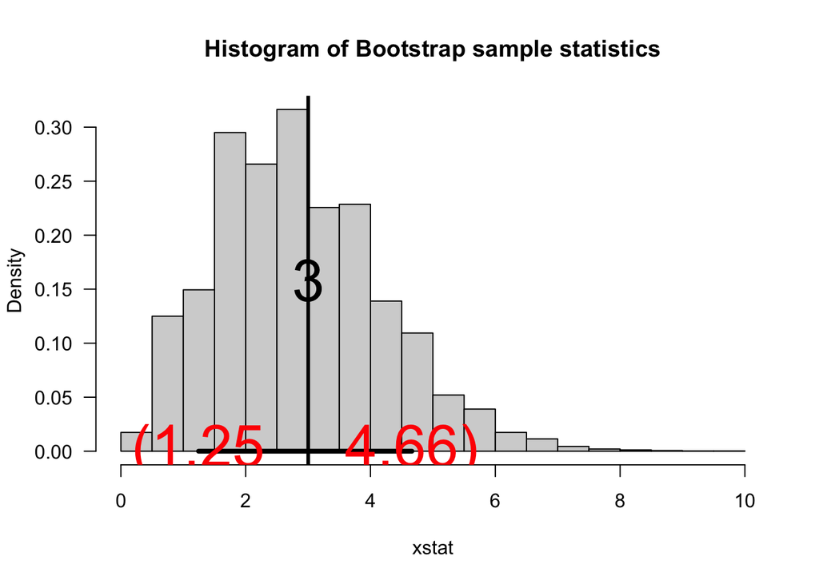

```
## $mean_ci
##        10%        90%
## -0.7918587  0.1525409
##
## $var_ci
##      10%      90%
## 1.245139 4.663153
```

```r
set.seed(120)
sam3=rt(20,df=3)
mean_var(sam3)
```

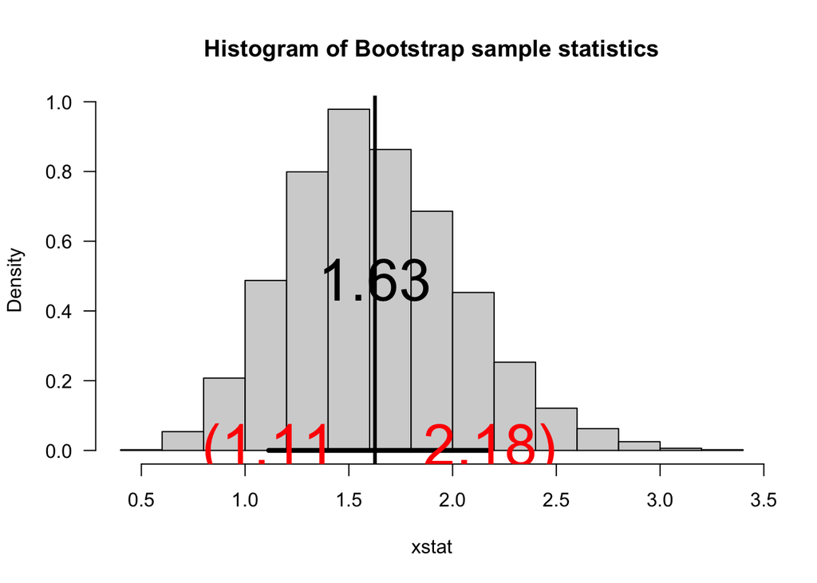

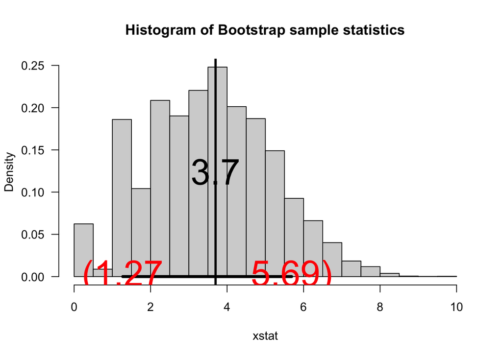

```
## $mean_ci
##     10%     90%
## 1.11363 2.18079
##
## $var_ci
##      10%      90%
## 1.271666 5.687543
```

```r
set.seed(130)
sam4=rlnorm(20,meanlog=0,sdlog=1)
mean_var(sam4)
```

# Task 7

```r
set.seed(68)
sam<-rnorm(20,mean=10,sd=4)
result_iqr <- myboot(iter=10000,x=sam,fun=IQR,alpha=0.05)
```

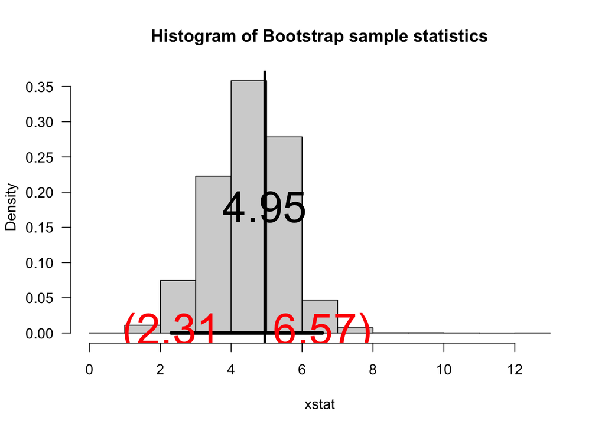

```r
result_iqr$ci
```

```
##     2.5%    97.5%
## 2.311129 6.573407
```

```r
result_sd <- myboot(iter=10000,x=sam,fun=sd,alpha=0.05)
```

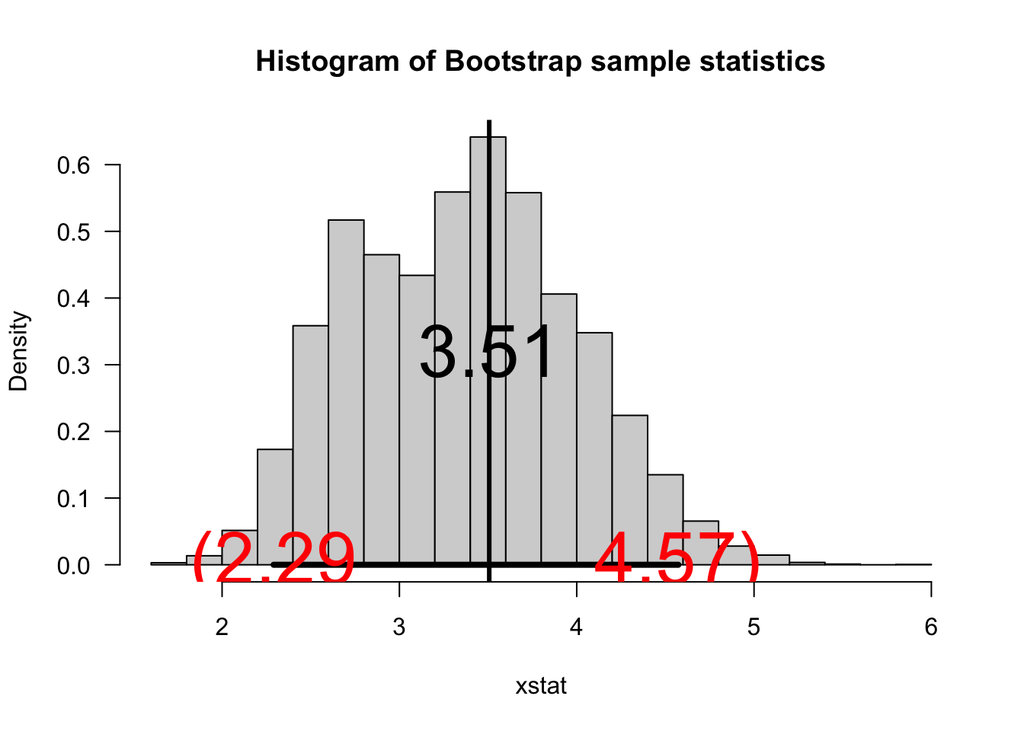

```r
result_sd$ci
```

```
##     2.5%    97.5%
## 2.290639 4.573095
```

```r
# calculate 95% confidence interval using theory
alpha <- 0.05

t <- qt(1 - alpha/2, 20-1)
mp <- c(-1, 1)

# manually calculated confidence interval
mean(sam) + mp * t * sd(sam)/sqrt(20)
```

```
## [1]  8.818145 12.100478
```

```r
sam_myboot<-myboot(iter=10000,x=sam,fun=mean,alpha=0.05)
```

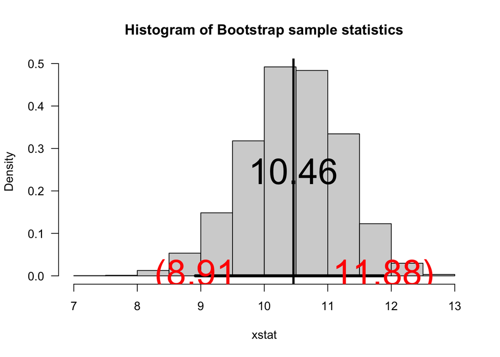

```r
sam_myboot$ci
```

```
##      2.5%     97.5%
##  8.914402 11.876523
```

The manually calculated confidence interval and functionally calculated interval are nearly identical. They have minimal differences.

# Task 8

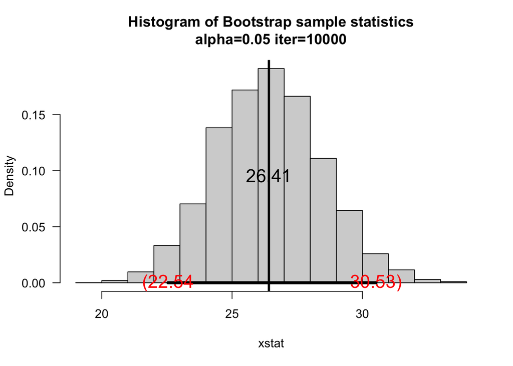

```r
MATH4753nguy0850::myboot2(x=MATH4753nguy0850::fire$DAMAGE)
```